# S35 Accelerator & Detector Physics

## Accelerator Physics by Professor Adrian Oeftiger

[figure not shown]

### Lecture 3: Transition Energy

## Run this notebook online!

Interact and run this jupyter notebook online:

via the local Physics Jupyterlab service:

via the public mybinder.org service:

Also find this lecture rendered [as HTML slides on github $\nearrow$](https://aoeftiger.github.io/UOXF-AP-2026/) along with the [source repository $\nearrow$](https://github.com/aoeftiger/UOXF-AP-2026).

## Run this first!

Imports and modules:

```python
from config import (np, plt, plot_rfwave, tqdm, trange, )
from scipy.constants import m_p, e, c
%matplotlib inline
```

## Refresher!

- Lorentz force, only longitudinal $E_z$ field component can accelerate
- energy gain in rf cavity: synchronous particle and real particles
- linacs
- phase focusing and stability $=$ bunching
- longitudinal particle tracking equations for linacs

## Today!

1. Synchrotrons
2. Momentum compaction and phase slippage
3. Transition energy
4. Hamiltonian for longitudinal dynamics
5. Simulation of CERN Proton Synchrotron

## Part I: Circular Accelerator Concepts

... or how Einstein's relativity hits back!

## Beam rigidity

Constant (dipole) magnetic field $B$ guides reference particle on circular trajectory with bending radius $\rho$:

$$\begin{align} F_\text{centrip} &= F_\text{L} \\ \frac{\gamma m_0 v^2}{\rho} &= |q| v B \end{align}$$

$$\stackrel{p\mathop{=}\gamma m_0 v}{\implies} \quad\text{Beam rigidity:}\qquad B\rho = \cfrac{p}{|q|}$$

## Synchrotron

[figure not shown]

- ring with a constant reference orbit of circumference $C$,  
  determined by the dipole magnets (defining the beam rigidity)
- RF systems powered at revolution frequency $f_{\text{rev}}$  
  or integer multiple of it ("harmonic" $h$): **synchronisation**!

$$\begin{align} f_{\text{rev}} &= \frac{\beta c}{C} \\ f_{\text{rf}} &\stackrel{!}{=} h\,f_{\text{rev}} \end{align}$$

$\implies$ $h$ synchronous particles moving along reference orbit! To accelerate them and for longitudinal phase focusing around them, apply $E_z$ in RF cavity!

$\implies$ only works with AC field! Why not DC field across cavity gap?

image by [A. Chance and N. Pichoff](https://npac.ijclab.in2p3.fr/wp-content/uploads/2020/Cours/Accelerators/Longitudinal_dynamics_doc.pdf)

## Acceleration in Synchrotron

[figure not shown]

Require (dipole) magnetic fields to *synchronise* with increasing momentum!

$$\underbrace{\dot{B}}\limits_{=\frac{dB}{dt}}=\frac{\dot{p}}{|q|\rho}$$

$\implies$ synchrotrons "cycle": magnets ramp up fields for acceleration (and back down to inject next beam)

image from [CERN Vistars](https://op-webtools.web.cern.ch/vistar/?usr=SPS1)

## Mechanism behind Synchrotron

Conceptual "flow chart" of synchrotron operation principle:

$\implies$ typically magnetic field ramp $\dot{B}$ is slow enough

$\implies$ adiabatic acceleration, particles remain focused around synchronous particle

## Off-momentum Trajectory

[figure not shown]

image by [Y. Hao](https://people.nscl.msu.edu/~haoy/teaching/fundamental_AP/transverse_dynamics/transverse_dynamics.html)

[figure not shown]

image by [BR84, Wikimedia](https://commons.wikimedia.org/wiki/File:ClassicMicrotronSketch.svg)

Particles with higher momentum, $\delta = \Delta p/p_0 > 0$, than the reference particle are bent less (larger $p$ $\implies$ larger $\rho$)!

$$\implies d\ell = \left(1 + \frac{x}{\rho(s)}\right) ds$$

$\implies$ larger equilibrium orbit around the machine for fixed dipole fields $B$!

Can describe this horizontal offset $x$ due to momentum offset $\delta$ by dispersion function $D_x(s)$ (more details later in lecture 6):

$$x(s) = D_x(s) \delta$$

Integrating around machine to get full orbit length:

$$\ell_\text{tot} = \oint d\ell = \underbrace{\oint ds}\limits_{\mathop{\equiv} C} + \delta \oint ds\,\frac{D_x(s)}{\rho(s)}$$

## Momentum Compaction Factor I

Relative difference in path length $\Delta C/C = (\ell_\text{tot} - C)/C$ around the ring compared to synchronous particle is therefore:

$$\frac{\Delta C}{C} = \delta~ \underbrace{\frac{1}{C} \oint ds\,\frac{D_x(s)}{\rho(s)}}\limits_{\mathop{\doteq}\alpha_c} = \alpha_c \frac{\Delta p}{p}$$

The momentum compaction factor expresses "how much longer the path length around the ring becomes for higher momenta"!

$$\text{Momentum compaction factor:}\qquad \alpha_c = \frac{1}{C} \oint ds\,\frac{D_x(s)}{\rho(s)}$$

## Momentum Compaction Factor II

$\rho=\infty$ in straight sections

$\implies$ $\alpha_c=\cfrac{2\pi\langle D_x \rangle_\text{mean}}{C}$ with the mean value referring to dipole $\mathbf{B}$ field areas only!

**Note:** $\alpha_c$ is an external (not a beam) property given by the magnet configuration.

$\leadsto$ What can you state about momentum compaction in a linac?

## Change of Arrival Time

How does the revolution period (or arrival time of a particle after one turn) $T_\text{rev}$ vary with momentum deviation $\delta$?

$$ T_\text{rev} = \frac{1}{f_\text{rev}} = \frac{C}{\beta c} $$

With logarithmic differentiation:

$$\frac{\Delta T_\text{rev}}{T_\text{rev}} = \underbrace{\frac{\Delta C}{C}}\limits_{\mathop{\equiv}\alpha_c\Delta p/p_0} - \underbrace{\frac{\Delta \beta}{\beta}}\limits_{\mathop{\equiv}\gamma^{-2}\Delta p/p_0}$$

$\implies$ additional influence of path length change compared to linacs!

## Phase-slip Factor

Collecting all terms for the arrival time deviation (the longitudinal drift):

$$\begin{align} \frac{\Delta T_\text{rev}}{T_\text{rev}} &= \alpha_c \frac{\Delta p}{p} - \frac{1}{\gamma^2}\cdot \frac{\Delta p}{p} \equiv \eta \delta \end{align}$$

The phase-slip factor expresses "how much arrival time delay a momentum offset causes"!

$$\text{Phase-slip factor:}\qquad \eta \doteq \alpha_c - \frac{1}{\gamma^2}$$

**Note:** $\eta$ changes with the particle energy via $\gamma$!

## Synchrotron: Longitudinal One-turn Map

The RF frequency needs to be synchronised with any change in $\beta$ as

$$\omega_\text{rf}=h\omega_\text{rev}=2\pi h / T_\text{rev} = 2\pi h \beta c/C \quad .$$

The **longitudinal tracking equations** from turn $n$ to $n+1$ in a synchrotron hence read

$$\begin{cases}\, z_{n+1} &= z_n - \eta C \left(\cfrac{\Delta p}{p_0}\right)_n \\ (\Delta p)_{n+1} &= (\Delta p)_n + \cfrac{q V}{(\beta c)_n}\cdot\left(\sin\left(\varphi_s - \cfrac{2\pi}{C}\cdot hz_{n+1}\right) - \sin(\varphi_s)\right) \end{cases}$$

with the synchronous phase $\varphi_s$ determined by $(\delta p_0)_{\text{turn}} = \frac{q V}{\beta c}\,\sin\bigl(\varphi_s\bigr)$.

## Transition Energy and Stability

Defining the **transition energy**, $$\gamma_\text{t} \doteq \frac{1}{\sqrt{\alpha_c}} \quad ,$$

(i.e. $\eta = 1/\gamma_\text{t}^2 - 1/\gamma^2$) can distinguish two regimes:

| **classical regime** | **relativistic regime** |
| --- | --- |
| $\eta < 0$ | $ \eta > 0$ |
| $\gamma < \gamma_\text{t}$ | $\gamma > \gamma_\text{t}$ |
| higher-momentum particles with $\delta>0$ are faster and arrive before synchronous particle | higher-momentum particles with $\delta>0$ have no velocity advantage ($\beta \rightarrow 1$) but longer path to cover and arrive after synchronous particle |
| $\implies$ choose $\varphi_s$ with rising slope of $qV(\varphi)$ | $\implies$ choose $\varphi_s$ with falling slope of $qV(\varphi)$ (i.e. $\pi-\varphi_s$ compared to below transition) |

$\leadsto$ What happens to phase focusing at $\gamma=\gamma_\text{t}$?

|  | $\gamma<\gamma_\text{t}$ | $\gamma>\gamma_\text{t}$ |
| --- | --- | --- |
| $\varphi>\varphi_s$ | $\color{blue}{\delta < 0}$ | $\color{orange}{\delta > 0}$ |
| $\varphi<\varphi_s$ | $\color{orange}{\delta > 0}$ | $\color{blue}{\delta < 0}$ |

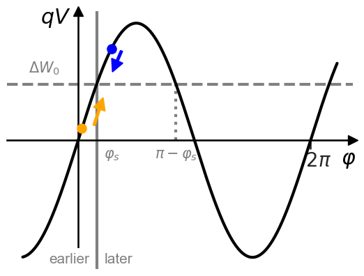

```python
plot_rfwave(phi_s=0.5, regime='classical'); # try 'relativistic'
```

## Longitudinal Differential Equations I

The longitudinal oscillation about a synchronous particle is generally called **synchrotron motion**.

To derive the Hamiltonian, we need to determine smooth (but approximative) differential equations from here.

Treat **adiabatic acceleration** case ($\beta=\mathrm{const}$ during RF cavity kick) in **smooth focusing approximation** (RF cavity effect all around the ring):

$\implies$ obtain **differential equations** via

- $z_{n+1}-z_n\leadsto \frac{dz}{ds}\cdot C$ and
- $\Delta p_{n+1}-\Delta p_n \leadsto \frac{d(\Delta p)}{ds}\cdot C$

$$\begin{cases}\, z_{n+1} &= z_n - \eta C \left(\cfrac{\Delta p}{p_0}\right)_n \\ (\Delta p)_{n+1} &= (\Delta p)_n + \cfrac{q V}{(\beta c)_n}\cdot\left(\sin\left(\varphi_s - \cfrac{2\pi}{C}\cdot hz_{n+1}\right) - \sin(\varphi_s)\right) \end{cases}$$

$\Downarrow$

Differential equations for synchrotron motion:

$$\begin{cases}\, \cfrac{dz}{ds} &= -\eta\cdot \cfrac{\Delta p}{p_0} \\ \cfrac{d(\Delta p)}{ds} &= \cfrac{q V}{C\beta c}\cdot \left(\sin\left(\varphi_s - \cfrac{2\pi}{C}\cdot hz\right) - \sin(\varphi_s)\right) \end{cases}$$

## Toward a Hamiltonian

A Hamiltonian $\mathcal{H}$ induces a flow on the phase space: solutions to equation of motion $\leftrightarrow$ iso-Hamiltonian lines $\mathcal{H}=\mathrm{const}$.

Integrate Hamilton equations to find (a sort of "instantaneous") $\mathcal{H}(z,\Delta p)=T(\Delta p) + U(z)$:

The first Hamilton equation determines the kinetic energy term $T(\Delta p)$,

$$\frac{dz}{ds} \stackrel{!}{=} \frac{\partial \mathcal{H}}{\partial (\Delta p)} \quad \stackrel{\int}{\implies} \quad \mathcal{H}(z,\Delta p) = \underbrace{-\frac{1}{2}\frac{\eta}{p_0} \Delta p{}^2}\limits_{T} + U(z) + \mathrm{const.} \quad ,$$ and the second Hamilton equation determines the potential energy $U(z)$: $\quad \cfrac{d(\Delta p)}{ds} \stackrel{!}{=} -\cfrac{\partial\mathcal{H}}{\partial z}$

## The Hamiltonian of Synchrotron Motion

Integration yields the Hamiltonian of **synchrotron motion**:

$$ \mathcal{H}(z,\Delta p)=-\frac{1}{2}\frac{\eta}{p_0} \Delta p{}^2 - \frac{qV}{\beta c}\cdot\frac{1}{2\pi h}\left(\cos\left(\varphi_s - \frac{2\pi h}{C}\cdot z\right) - \frac{2\pi h}{C}\cdot z\cdot \sin(\varphi_s)\right)$$

## Stationary Case and Small-amplitude Approximation

For the stationary case $\sin(\varphi_s)=0$, we recover the **simple pendulum** Hamiltonian if $\varphi_s=0$ below or $\varphi_s=\pi$ above transition,

$$\mathcal{H}_\mathrm{stat}(z,\Delta p) = -\frac{1}{2}\frac{\eta}{p_0} {\color{red}{\Delta p{}^2}} -\frac{qV}{\beta c}\cdot\frac{1}{2\pi h}{\color{red}{\cos\left(\varphi_s - \frac{2\pi h}{C}\cdot z\right)}} $$

Remember, this expresses again the phase focusing requirement on $\varphi_s$!

For small $z$ around the synchronous particle (stable fixed point!), expand $\cos(x)\approx 1-x^2/2 + \mathcal{O}(x^4)$:

$$\mathcal{H}_\mathrm{stat,small}(z,\Delta p) = -\mathrm{sgn}(\eta)\cdot\left[\frac{1}{2}\frac{|\eta|}{p_0} {\color{red}{\Delta p{}^2}} + \frac{qV}{\beta c}\cdot \cfrac{\pi h}{C^2}\cdot {\color{red}{z^2}}\right] $$

$\implies$ **Hamiltonian of harmonic oscillator!**

## Synchrotron Tune I

The small-amplitude case (small $z$) yields the linear oscillation frequency of the particles, commonly referred to as "tune" when relating to oscillations per turn. Assemble the 2nd-order ODE from the two 1st-order coupled ODEs:

$$\frac{dz^2}{ds^2}+\frac{\eta q V}{p_0 \beta c C}\cdot \left(\underbrace{\sin\left(\varphi_s - \frac{2\pi}{C} h z\right)}\limits_{\mathop{=}\sin(\varphi_s)\cos\left(\frac{2\pi}{C}hz\right) - \cos(\varphi_s)\sin\left(\frac{2\pi}{C}hz\right)} - \sin(\varphi_s)\right) = 0$$

Linearising in $z$ gives

$$\sin\left(\varphi_s - \frac{2\pi}{C} h z\right) \approx \sin(\varphi_s) - \cos(\varphi_s)\cdot\frac{2\pi}{C} h z + \mathcal{O}(z^2)$$

## Synchrotron Tune II

Therefore the linearised ODE of 2nd order (harmonic oscillator ODE) reads

$$\frac{dz^2}{ds^2}+\underbrace{\frac{-\eta q V \cdot 2\pi h \cos(\varphi_s)}{p_0 \beta c C^2}}\limits_{\mathop{\equiv}\Omega_s^2}\cdot z = 0$$

and the **synchrotron tune** $Q_s$ (longitudinal oscillations per turn) evaluates to
$$Q_s^2=\frac{\omega_s^2}{\omega_\mathrm{rev}{}^2} = \frac{\Omega_s^2}{(2\pi/C)^2} = \frac{-\eta h q V \cos(\varphi_s)}{2\pi p_0 \beta c}$$

## Comprehension Questions I

1. Why is the RF frequency an integer multiple (the "harmonic" $h$) of the revolution frequency?
2. Given a typical ring layout (due to the bending magnets, the dipoles):  
   a) Is the experienced circumference larger or smaller for particles with $\delta > 0$ (larger momentum than the synchronous particle)?  
   b) How is this effect called?  
   c) What happens to this effect / quantity when the bending radius becomes infinite (a.k.a. linear accelerator)?

## Comprehension Questions II

3. The $\eta$ parameter is also called "phase-slip factor". It relates the arrival time (or frequency) with the momentum.  
   a) What is the qualitative reason for the dependency of $\eta$ on the energy / momentum?  
   b) At low energies with $\gamma < \gamma_\text{t}$: do particles with $\delta < 0$ arrive before or after particles with $\delta > 0$?  
   c) Same as b) but for high energies with $\gamma > \gamma_\text{t}$.
4. Which parameter does an operator in the control room change to make a synchrotron accelerate the particles? The dipole magnet strength or the RF cavity timing? (i.e. which of the two parameters depends on the other?)

## Part II: Simulation of Synchrotron Motion in the CERN Proton Synchrotron

The world's first synchrotron (1959), delivering beams to the LHC today!

[figure not shown]

images by [P. Loïez](https://cds.cern.ch/record/42477) and [CERN](http://cds.cern.ch/images/CERN-GRAPHICS-2022-001-1)

## CERN PS Parameters

Some convenience functions to compute the speed β and the relativistic Lorentz factor γ:

```python
def beta(gamma):
    '''Speed β in units of c from relativistic Lorentz factor γ.'''
    return np.sqrt(1 - gamma**-2)

def gamma(p):
    '''Relativistic Lorentz factor γ from total momentum p.'''
    return np.sqrt(1 + (p / (mass * c))**2)
```

We gather all the machine parameters in a class named `Machine` to represent the CERN PS.

A `Machine` instance knows

- at which energy the synchronous particle (reference $\gamma_\text{ref}$, `gamma_ref`, or alternatively the momentum `p0()`) currently runs,
- what the acceleration rate is in terms of the synchronous phase $\varphi_s$, `phi_s`
- how to compute the phase-slip factor $\eta$, `eta`, for a particle at a certain momentum $p_0 + \Delta p$
- how to update the energy of the synchronous particle via `update_gamma_ref()` when a turn has passed

```python
charge = e
mass = m_p

class Machine(object):
    # units: SI, phi_s in rad:
    gamma_ref = 3.13 #fill me
    circumference = 2 * np.pi * 100 #fill me
    voltage = 50e3 #fill me
    harmonic = 7 #fill me
    alpha_c = 0.027 #fill me
    phi_s = 0.456 #fill me

    def __init__(self, gamma_ref=gamma_ref, circumference=circumference,
                 voltage=voltage, harmonic=harmonic,
                 alpha_c=alpha_c, phi_s=phi_s):
        '''Override default settings by giving explicit arguments.'''
        self.gamma_ref = gamma_ref
        self.circumference = circumference
        self.voltage = voltage
        self.harmonic = harmonic
        self.alpha_c = alpha_c
        self.phi_s = phi_s

    def eta(self, deltap):
        '''Phase-slip factor for a particle.'''
        p = self.p0() + deltap
        return self.alpha_c - gamma(p)**-2

    def p0(self):
        '''Momentum of synchronous particle.'''
        return self.gamma_ref * beta(self.gamma_ref) * mass * c

    def update_gamma_ref(self):
        '''Advance the energy of the synchronous particle
        according to the synchronous phase by one turn.
        '''
        deltap_per_turn = charge * self.voltage / (
            beta(self.gamma_ref) * c) * np.sin(self.phi_s)
        new_p0 = self.p0() + deltap_per_turn
        self.gamma_ref = gamma(new_p0)
```

## Hamiltonian landscape in longitudinal plane

Now we define the kinetic and potential energy terms:

```python
def T(deltap, machine):
    '''Kinetic energy term in Hamiltonian.'''
    return -0.5 * machine.eta(deltap) / machine.p0() * deltap**2

def U(z, machine, beta_=None):
    '''Potential energy term in Hamiltonian.
    If beta is not given, compute it from synchronous particle.
    '''
    m = machine
    if beta_ is None:
        beta_ = beta(gamma(m.p0()))
    ampl = charge * m.voltage / (beta_ * c * 2 * np.pi * m.harmonic)
    phi = m.phi_s - 2 * np.pi * m.harmonic / m.circumference * z
    # convenience: define z at unstable fixed point
    z_ufp = -m.circumference * (np.pi - 2 * m.phi_s) / (2 * np.pi * m.harmonic)
    # convenience: offset by potential value at unstable fixed point
    # such that unstable fixed point (and separatrix) have 0 potential energy
    return ampl * (-np.cos(phi) +
                   2 * np.pi * m.harmonic / m.circumference * (z - z_ufp) * np.sin(m.phi_s) +
                   -np.cos(m.phi_s))
```

...and the Hamiltonian function(al) itself:

```python
def hamiltonian(z, deltap, machine):
    return T(deltap, machine) + U(z, machine, beta_=beta(gamma(machine.p0() + deltap)))
```

Some plotting helper functions:

```python
from config import plot_hamiltonian, plot_rf_overview
```

### Setting up the PS

The `Machine` instance will keep track of the reference energy during the tracking by calling `update_gamma_ref()` once per turn.

You can override the default PS parameters by supplying arguments to the `Machine(...)` instantiation, e.g. change the `gamma_ref` by `m = Machine(gamma_ref=20)` or the `phi_s` etc.

```python
m = Machine(phi_s=0)
```

Let's plot the Hamiltonian landscape on phase space:

$\implies$ the closed area inside the blue **separatrix** is typically referred to as **"RF bucket"**!

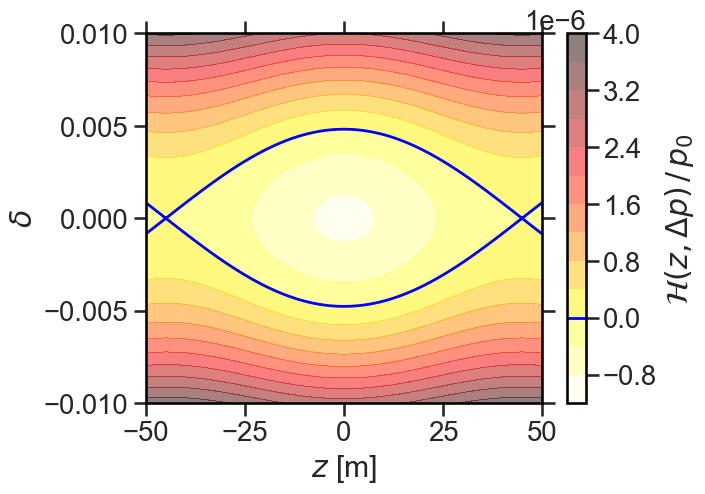

```python
plot_hamiltonian(m)
```

## Exercises based on Hamiltonian

Change the settings of `Machine` (notably `phi_s` and `gamma_ref`) here to explore the consequences on the Hamiltonian landscape (and hence the predicted particle orbits).

1. For $\varphi_s=0$, compare the stationary situation of the synchronous particle to a nonlinear pendulum:
   1. What is the meaning of a $\varphi_s=0,\pi$ synchronous phase offset in terms of the pendulum?
   2. What state of a pendulum does the stable fixed point, and the unstable fixed point, correspond to?
2. What happens to the separatrix / rf bucket for a small change around $\varphi_s=0$? Use the `plot_rf_overview` function below to visualise the potential.
3. For $\varphi_s=0$, what happens if you set an energy above transition? You will need to compute $\gamma_t=1/\sqrt{\alpha_c}$.
4. Calculate the correct $\varphi_s$ to achieve the acceleration rate of $\dot{B}=2$ T/s. You may use the convenience functions below. What is the fractional increase in the reference momentum per turn, $(\delta p_0)_\text{turn}/p_0$? What happens to the separatrix?

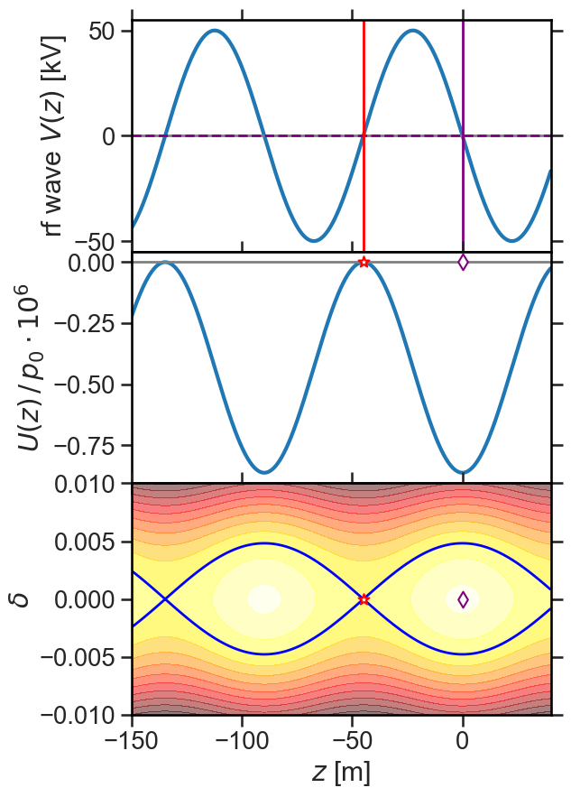

```python
plot_rf_overview(m);
```

To compute a synchronous phase $\varphi_s$, you may use these convenience functions to compute the $\arcsin$ on the interval of [-π/2,π/2] .

```python
def deltap_per_turn(Bdot, rho, circumference, p0):
    Trev = circumference / (beta(gamma(p0)) * c)
    return Bdot * rho * charge * Trev
```

```python
def compute_phi_s(deltap_per_turn, p0, voltage):
    '''Return *first* positive phase which matches the
    given Δp/turn on the interval [0, π/2].
    Do check whether you need to use π-φ_s for stability!
    '''
    return np.arcsin(
        deltap_per_turn * beta(gamma(p0)) * c / (charge * voltage)
    )
```

Compute the synchronous phase:

(NB: Remember you may likely want to find a synchronous phase on $\varphi_s\in[0,π]$ (why?)!)

## Particle Tracking

As a reminder, the tracking equations for the longitudinal plane read:

$$\begin{cases}\, z_{n+1} &= z_n - \eta C \left(\cfrac{\Delta p}{p_0}\right)_n \\ (\Delta p)_{n+1} &= (\Delta p)_n + \cfrac{q V}{(\beta c)_n}\cdot\left(\sin\left(\varphi_s - \cfrac{2\pi}{C}\cdot hz_{n+1}\right) - \sin(\varphi_s)\right) \end{cases}$$

```python
def track_one_turn(z_n, deltap_n, machine):
    m = machine
    # drift
    z_n1 = z_n - m.eta(deltap_n) * deltap_n / m.p0() * m.circumference
    # rf kick
    amplitude = charge * m.voltage / (beta(gamma(m.p0())) * c)
    phi = m.phi_s - m.harmonic * 2 * np.pi * z_n1 / m.circumference

    m.update_gamma_ref()
    deltap_n1 = deltap_n + amplitude * (np.sin(phi) - np.sin(m.phi_s))
    return z_n1, deltap_n1
```

Setting up the PS `Machine` for tracking:

(*hint: hit both `Shift+Tab` keys inside the parentheses `()` below to get info about the possible arguments to `Machine`*)

```python
m = Machine(phi_s=0, gamma_ref=3.13) #, voltage=...)
```

Particle trajectories are tracked by their two longitudinal coordinates $(z, \Delta p)$. The initial values are stored in `z_ini` and `deltap_ini` as `numpy.array`s. These should have `N` entries for $N$ particles.

(You may use numpy helper functions such as `np.linspace` or `np.arange` for convenient initialisation!)

```python
n_turns = 500 # change me
deltap_ini = np.linspace(0, 0.01 * m.p0(), 20) # change me
z_ini = np.zeros_like(deltap_ini) # replace me

N = len(z_ini)
assert (N == len(deltap_ini))
```

To store the coordinate values during tracking, prepare some `n_turns` long 2D arrays with `N` entries per turn:

```python
z = np.zeros((n_turns, N), dtype=np.float64)
deltap = np.zeros_like(z)

z[0] = z_ini
deltap[0] = deltap_ini
```

Record the evolution of energy $\gamma_\mathrm{ref}$ and also Hamiltonian values of particles during tracking:

```python
gammas = np.zeros(n_turns, dtype=np.float64)
gammas[0] = m.gamma_ref

H_values = np.zeros_like(z)
H_values[0] = hamiltonian(z_ini, deltap_ini, m) / m.p0()
```

### Tracking Loop

Let's go, here's the tracking loop over the number of turns `n_turns`!

```python
for i_turn in range(1, n_turns):
    # track & record:
    z[i_turn], deltap[i_turn] = track_one_turn(z[i_turn - 1], deltap[i_turn - 1], m)
    # record:
    gammas[i_turn] = m.gamma_ref
    H_values[i_turn] = hamiltonian(z[i_turn], deltap[i_turn], m) / m.p0()
```

### Change of energy during simulation

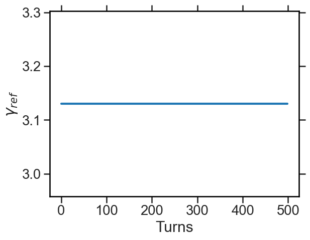

```python
plt.plot(gammas)
plt.xlabel('Turns')
plt.ylabel('$\gamma_{ref}$')
```

### Phase space evolution during simulation

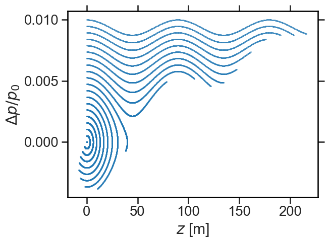

```python
# plot_hamiltonian(m); # uncomment me

plt.scatter(z, deltap / m.p0(), marker='.', s=0.5)
plt.xlabel('$z$ [m]')
plt.ylabel('$\Delta p/p_0$')
```

### Evolution of Hamiltonian / energy value during simulation

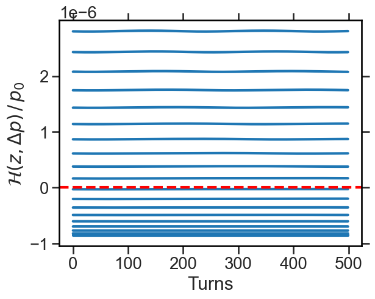

```python
plt.plot(H_values, c='C0');
plt.axhline(0, c='r', ls='--')
plt.xlabel('Turns')
plt.ylabel(r'$\mathcal{H}(z,\Delta p)\,/\,p_0$');
```

### Overview of longitudinal phase space landscape

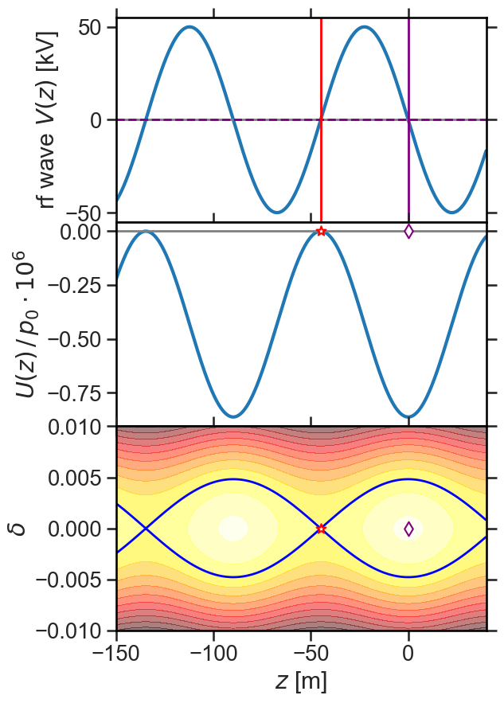

```python
plot_rf_overview(m);
```

## Exercises based on Tracking

Modify the machine parameters (and initial coordinates of particles) starting here to answer the following questions:

1. For $\varphi_s=0$, can you identify which particles are stably focused inside the RF bucket, and which ones are unbound outside?
2. For the correct $\varphi_s>0$, what happens to particles outside the RF bucket now?
3. Do the Hamiltonian contours predict the tracked particle trajectories well?
4. CERN PS accelerates protons from $\gamma=3.1$ up to $\gamma=27.7$. Is the transition energy crossed during acceleration? What does this mean for the setting of the synchronous phase $\varphi_s$ in the control room?
5. What happens to phase focusing at the transition energy $\gamma=\gamma_\mathrm{t}$? Can you explain why? (Think of the phase slippage mechanism.)

$\implies$ please make sure you understand the answers to these questions: the concepts are central to accelerator physics and relevant for the exam.

## Summary

- beam rigidity equation: $B\rho=p/|q|$
- synchrotron principle, $f_\text{rf}=h\cdot f_\text{rev}$ with harmonic $h\in\mathbb{N}$
- momentum compaction $\alpha_c$ and phase-slip factor $\eta=\gamma_t^{-2}-\gamma^{-2}$
- transition energy $\gamma_t$
- longitudinal particle tracking equations for synchrotrons
- ordinary differential equations and Hamiltonian for synchrotron motion
- synchrotron tune

## Bonus Exercise: Realistic Beam Simulation

In the following, let us properly simulate the **full acceleration ramp** (including crossing transition) with a realistic bunch. It shall be Gaussian distributed and cover a small phase-space area, referred to as a bunch of "small emittance" (phase-space area)!

You as operator in the (simulation) control centre shall pay attention to **ensure stable phase focusing (and therefore preserve the longitudinal emittance)** throughout the acceleration!

$\implies$ Investigate the tracking results. Can you explain what happens? Think about what you need to change in the machine settings to achieve emittance preservation.

```python
m = Machine(phi_s=0.456)#fill me)

assert m.phi_s > 0, "machine is not accelerating...?"
```

We initialise a Gaussian bunch distribution with very small rms bunch length $\sigma_z=1\,$m (is this small compared to the RF bucket length? Would the small-amplitude Hamiltonian approximation be expected to hold, accordingly?):

```python
sigma_z = 1
```

The "matched" rms momentum spread $\sigma_{\Delta p}$:

(NB: a matched distribution is in equilibrium. $\sigma_{\Delta p}$ and $\sigma_z$ are linked to each other via equal Hamiltonian values $\mathcal{H}_0$, as they should both correspond to the same iso-Hamiltonian contour – that is the equilibrium condition.)

```python
sigma_deltap = np.sqrt(
    2 * m.p0() / -m.eta(0) *
    charge * m.voltage * np.pi * m.harmonic / (beta(gamma(m.p0())) * c * m.circumference**2)
) * sigma_z
```

```python
N = 1000
```

```python
np.random.seed(12345)

z = np.random.normal(loc=0, scale=sigma_z, size=N)
deltap = np.random.normal(loc=0, scale=sigma_deltap, size=N)
```

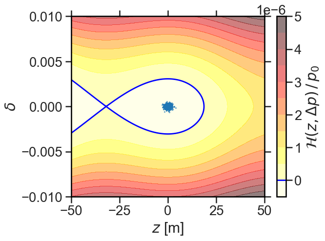

```python
plot_hamiltonian(m)
plt.scatter(z, deltap / m.p0(), marker='.', s=1);
```

### Compute Duration of Ramp

$(\Delta\gamma)_\mathrm{turn} = \cfrac{\Delta E_\mathrm{tot}}{m_0c^2} = \cfrac{qV\sin(\varphi_s)}{m_0c^2}$

such that accelerating from $\gamma_\mathrm{ref}=3.1$ to $\gamma_\mathrm{ref}=27.7$ takes as many turns as

$n_\mathrm{turns}=\cfrac{27.7-3.1}{(\Delta\gamma)_\mathrm{turn}}$

```python
dgamma_per_turn = charge * m.voltage * np.sin(m.phi_s) / (mass * c**2)
n_turns = int(np.ceil((27.7 - 3.13) / dgamma_per_turn))
n_turns
```

```
1047022
```

Record longitudinal emittance during tracking:

```python
from config import emittance
```

```python
epsn_z = np.zeros(n_turns, dtype=np.float64)

epsn_z[0] = emittance(z, deltap)
```

Let's go tracking! ($\approx 1\,$min total time)

```python
for i_turn in trange(1, n_turns):
    z, deltap = track_one_turn(z, deltap, m)

    epsn_z[i_turn] = emittance(z, deltap)
```

Have we reached the extraction energy of $\gamma=27.7$?

```python
m.gamma_ref
```

```
np.float64(27.699981145999953)
```

### How did we do?

Check that we properly conserved a constant rms emittance:

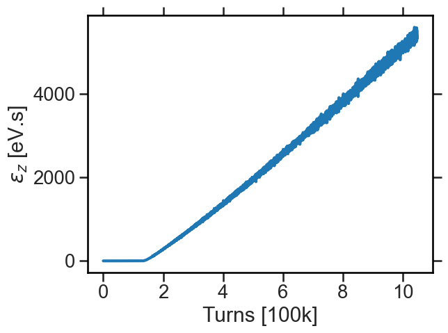

```python
plt.plot(np.arange(n_turns) / 100000, epsn_z / e)

plt.xlabel('Turns [100k]')
plt.ylabel('$\epsilon_z$ [eV.s]');
```

$\implies$ use the following phase-space plot besides the plotting functions `plot_hamiltonian` and `plot_rf_overview` above as **diagnostics**. You can stop the tracking after a certain turn to investigate, e.g. by changing the value of `n_turns` inside the `trange` counter in the `for` loop.

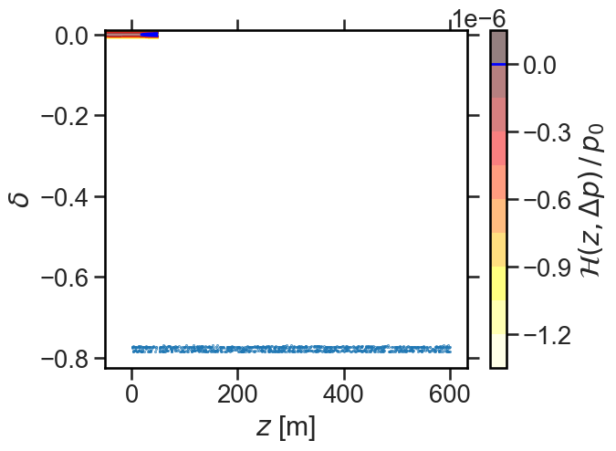

```python
plot_hamiltonian(m);
plt.scatter(z % 600, deltap / m.p0(), marker='.', s=1);
```

*If the progress bar by `tqdm` (`trange`) in this document does not work, run this:*

```python
!jupyter nbextension enable --py widgetsnbextension
```

```
Enabling notebook extension jupyter-js-widgets/extension...
      - Validating: OK
```